# 4th Floor Fantast Draft 2018

Evan Oman

August 27, 2018

## Introduction

The analysis below explores the performance of my friends during our 2018 Fantasy Football Draft. Since last year we have been drafting in a no-cheatsheet environment which means that each drafter must know who they are going to draft before the draft starts. As such the performance of each drafter could vary wildly and is thus an interesting phenomena to explore.

Note that I am using the ESPN Top 300 PPR rankings as a proxy for ground truth. Many of the rankings there are debatable but I think overall it gives a good rough estimate of each player’s value.

The source and data for this project are available at https://github.com/EvanOman/FantasyFootball2018. My contact info is available on my website: http://www.evanoman.com.

Let the fun begin!

## Data Preparation

First we load in the draft data. Unlike previous years, this data is already in the format we want so there is no need for `melt` or `reshape`.

```r
draftData <- read.csv("./data/Draft2018.csv", stringsAsFactors = F)
print.data.frame(head(draftData), row.names=FALSE)
```

```
##           Player  Drafter      Round
##  Ezekiel Elliott  Michael  Franchise
##      Julio Jones     Evan  Franchise
##     Le'Veon Bell     Will  Franchise
##     Alvin Kamara    Jacob  Franchise
##    David Johnson   Andrew  Franchise
##        Tom Brady Kuuuuuby  Franchise
```

As you can see, the data is already in the tall format. We will now drop the franchise players and tweak the dataset:

```r
# Save the franchise players for later
franchisePlayers <- draftData[1:8,"Player"]

# Drop the franchise players
draftData <- draftData[9:nrow(draftData),]

# Drop the row names
rownames(draftData) <- NULL

# Assign pick numbers sequentially
draftData$PickNumber <- 1:nrow(draftData)

# Makes the rounds numeric
draftData$Round <- as.numeric(draftData$Round)

print.data.frame(head(draftData, n=10), row.names=FALSE)
```

```
##             Player  Drafter Round PickNumber
##     Saquon Barkley  Michael     1          1
##      Antonio Brown     Evan     1          2
##        Kareem Hunt     Will     1          3
##    DeAndre Hopkins    Jacob     1          4
##         A.J. Green   Andrew     1          5
##      Melvin Gordon Kuuuuuby     1          6
##    Devonta Freeman      Joe     1          7
##  Odell Beckham Jr.    Chris     1          8
##     Michael Thomas    Chris     2          9
##      Davante Adams      Joe     2         10
```

Now that the draft data has been prepped, we can load in the rankings data:

```r
rankings <- read.csv("./data/EspnPprRankings2018.csv", stringsAsFactors = F)

# Read player as string, not factor
rankings$Player <- as.character(rankings$Player)

print.data.frame(head(rankings, n=10), row.names=FALSE)
```

```
##  Rank            Player Pos
##     1      Le'Veon Bell  RB
##     2    Todd Gurley II  RB
##     3     David Johnson  RB
##     4   Ezekiel Elliott  RB
##     5     Antonio Brown  WR
##     6    Saquon Barkley  RB
##     7      Alvin Kamara  RB
##     8       Julio Jones  WR
##     9   DeAndre Hopkins  WR
##    10 Odell Beckham Jr.  WR
```

This dataset is already in the tall format we want so there will be no reformating needed. However we will need to remove the `Franchise` players from the rankings set and adjust the rankings of the remaining players. This can be accomplished by filtering out the players in `franchisePlayers` and then reranking the remaining players in consecutive order.

```r
# Remove franchise players
rankings <- rankings[!(rankings$Player %in% franchisePlayers), ]

# Apply consecutive ranking to remaining players
rankings$Rank <- 1:nrow(rankings)

print.data.frame(head(rankings, n=10), row.names=FALSE)
```

```
##  Rank            Player Pos
##     1     Antonio Brown  WR
##     2    Saquon Barkley  RB
##     3   DeAndre Hopkins  WR
##     4 Odell Beckham Jr.  WR
##     5       Kareem Hunt  RB
##     6       Dalvin Cook  RB
##     7      Keenan Allen  WR
##     8     Melvin Gordon  RB
##     9    Michael Thomas  WR
##    10        A.J. Green  WR
```

Now that this final step has been performed we can just join `draftData` with `rankings` by `Player`. Note that this is a left join by default so the resulting dataframe will only contain rows from our draft dataframe. The ranking dataset only includes the top 300 players. Thus some players will not have a ranking so after the join these players will have a `NA` rank. We will replace this with the worst possible ranking (`nrow(rankings)`) plus `1`.

```r
library("plyr")

# Join rankings data with draft data
joinedData <- join(draftData, rankings, by="Player")

# Some players will not have a  ranking, give these players a worst ranking + 1
joinedData$Rank[is.na(joinedData$Rank)] <- nrow(rankings) + 1

print.data.frame(head(joinedData, n=10), row.names=FALSE)
```

```
##             Player  Drafter Round PickNumber Rank Pos
##     Saquon Barkley  Michael     1          1    2  RB
##      Antonio Brown     Evan     1          2    1  WR
##        Kareem Hunt     Will     1          3    5  RB
##    DeAndre Hopkins    Jacob     1          4    3  WR
##         A.J. Green   Andrew     1          5   10  WR
##      Melvin Gordon Kuuuuuby     1          6    8  RB
##    Devonta Freeman      Joe     1          7   12  RB
##  Odell Beckham Jr.    Chris     1          8    4  WR
##     Michael Thomas    Chris     2          9    9  WR
##      Davante Adams      Joe     2         10   13  WR
```

We now have a dataframe with each draft pick with the corresponding pick number and player ranking. We can then use the pick number and player ranking to measure the quality of each draft pick.

```r
joinedData$RankDiff <- joinedData$Rank - joinedData$PickNumber

print.data.frame(head(joinedData, n=10), row.names=FALSE)
```

```
##             Player  Drafter Round PickNumber Rank Pos RankDiff
##     Saquon Barkley  Michael     1          1    2  RB        1
##      Antonio Brown     Evan     1          2    1  WR       -1
##        Kareem Hunt     Will     1          3    5  RB        2
##    DeAndre Hopkins    Jacob     1          4    3  WR       -1
##         A.J. Green   Andrew     1          5   10  WR        5
##      Melvin Gordon Kuuuuuby     1          6    8  RB        2
##    Devonta Freeman      Joe     1          7   12  RB        5
##  Odell Beckham Jr.    Chris     1          8    4  WR       -4
##     Michael Thomas    Chris     2          9    9  WR        0
##      Davante Adams      Joe     2         10   13  WR        3
```

At this point all of the data has been prepped so we are ready to generate some plots and do a bit of analysis.

## Figures and Results

Probably the most natural measure of performance would be to look at the average difference between pick number and rank, across all rounds, organized by Drafter. We can calculate this using `aggregate`.

```r
avgDiffs <- aggregate(RankDiff ~ Drafter, joinedData, FUN=mean)

# Order factor by worst draft to best
avgDiffs <- within(avgDiffs, Drafter <- factor(Drafter, levels=avgDiffs[order(avgDiffs$RankDiff), "Drafter"]))

# Order dataframe by worst draft to best
avgDiffs <- avgDiffs[order(avgDiffs$RankDiff, decreasing = FALSE),]

print.data.frame(avgDiffs, row.names=FALSE)
```

```
##   Drafter    RankDiff
##     Chris  0.06666667
##      Will  5.13333333
##      Evan  8.60000000
##       Joe 22.66666667
##  Kuuuuuby 26.93333333
##     Jacob 27.73333333
##    Andrew 43.86666667
##   Michael 44.73333333
```

Thus we can see that Chris had the best draft (on average he got players 0.0666667 positions over rank value) and Michael had the worst (on average, he got players 44.7333333 positions over rank value). Here is a quick visual of the above dataframe.

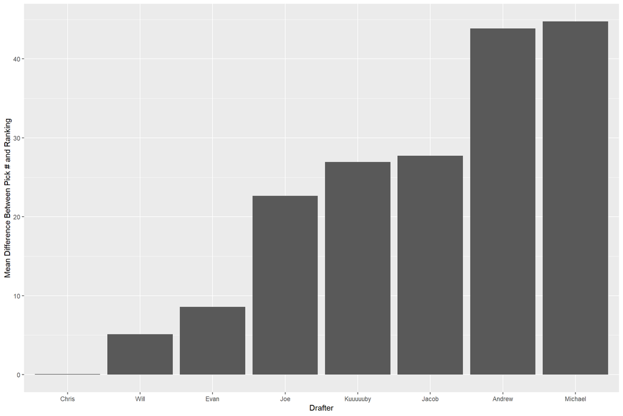

```r
library(ggplot2)
ggplot(avgDiffs, aes(x=Drafter, y=RankDiff)) + geom_bar(stat = "identity") + ylab("Mean Difference Between Pick # and Ranking")
```

Since kickers and defenses are generally ranked very low, and because I picked a bad kicker and defense, I was curious to see what these rankings look like without those position types:

```r
noKorDst <- joinedData[!(joinedData$Pos %in% list("DST", "K")), ]

avgDiffs2 <- aggregate(RankDiff ~ Drafter, noKorDst, FUN=mean)

# Order factor by worst draft to best
avgDiffs2 <- within(avgDiffs2, Drafter <- factor(Drafter, levels=avgDiffs[order(avgDiffs$RankDiff), "Drafter"]))

# Order dataframe by worst draft to best
avgDiffs2 <- avgDiffs2[order(avgDiffs2$RankDiff, decreasing = FALSE),]

print.data.frame(avgDiffs2, row.names=FALSE)
```

```
##   Drafter  RankDiff
##     Chris -8.153846
##      Will -3.923077
##  Kuuuuuby  4.727273
##      Evan  5.214286
##       Joe 11.384615
##     Jacob 14.923077
##   Michael 34.214286
##    Andrew 43.071429
```

I was curious to see how undervalued/overvalued players were by position. We can use a similar methodology as above to figure this out.

```r
posDiffs <- aggregate(RankDiff ~ Pos, joinedData, FUN=mean)

posDiffs <- within(posDiffs, Pos <- factor(Pos, levels=posDiffs[order(posDiffs$RankDiff), "Pos"]))

# Order dataframe by worst draft to best
posDiffs <- posDiffs[order(posDiffs$RankDiff, decreasing = FALSE),]

print.data.frame(posDiffs, row.names=FALSE)
```

```
##  Pos RankDiff
##   WR -4.00000
##   RB  9.43750
##   TE 12.15385
##   QB 40.61538
##    K 77.16667
##  DST 93.44444
```

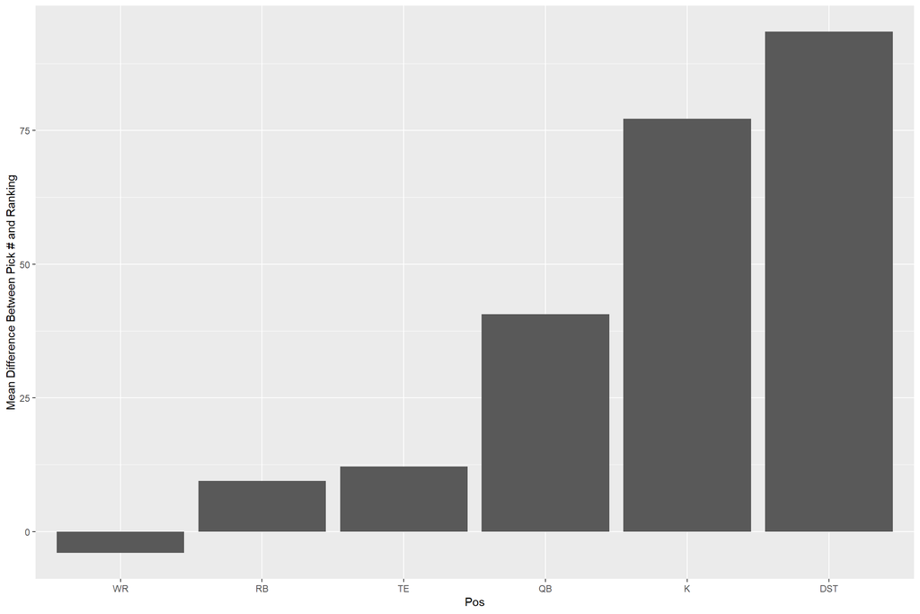

```r
ggplot(posDiffs, aes(x=Pos, y=RankDiff)) + geom_bar(stat = "identity") + ylab("Mean Difference Between Pick # and Ranking")
```

Here we can see that WR were under valued by 4 positions and DST were overvalued by 93.4444444 positions.

I was also curious to see how draft pick quality changed by round. In the next two figures I am plotting `Pick #` vs `Rank` with a diagonal line indicating a pick at the rank value. Thus all picks below this line are “good” and all of the above are “bad”. In the first figure I colored the picks by Drafter and in the second I am coloring by position.

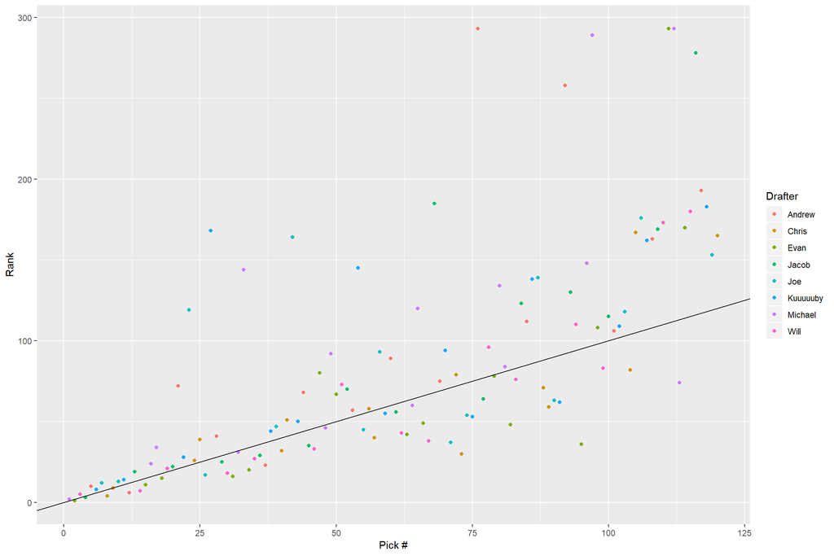

```r
# Scatter colored by drafter
ggplot(joinedData, aes(x=PickNumber,y=Rank)) + geom_point(aes(color=Drafter)) + geom_abline() + xlab("Pick #")
```

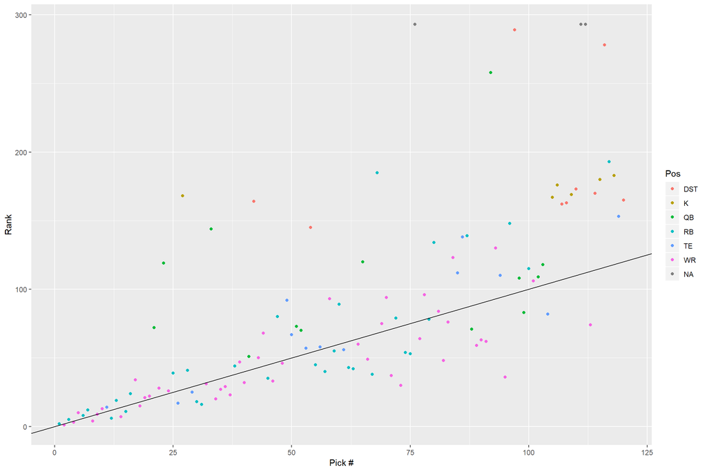

```r
# Scatter colored by position
ggplot(joinedData, aes(x=PickNumber,y=Rank)) + geom_point(aes(color=Pos)) + geom_abline() + xlab("Pick #")
```

It is pretty clear that as time goes on, worse and worse picks made.

Finally I wanted to see how each drafter performed by round, the following figure accomplishes this (here any pick below the dashed line is “good” and anything above the dased line is “bad”).

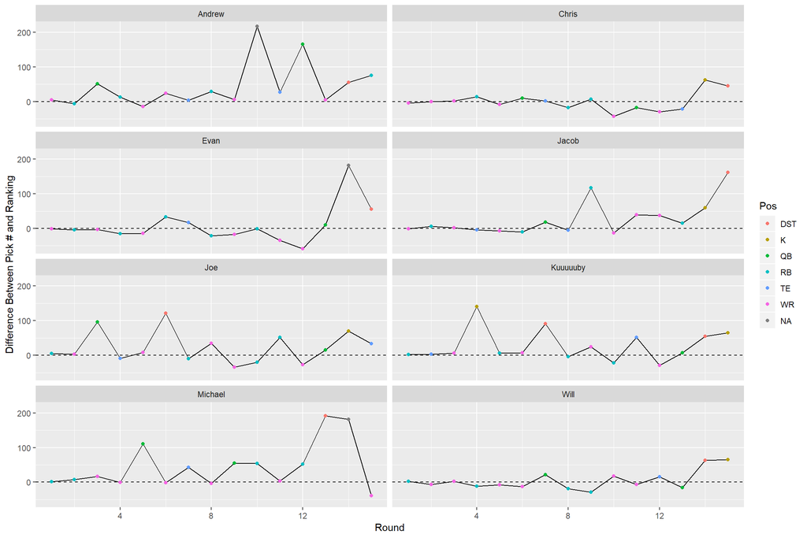

```r
# Scatter colored by position, faceted by drafer
ggplot(joinedData, aes(x=Round, y=RankDiff)) + geom_line() + facet_wrap(~Drafter, ncol=2) + geom_hline(yintercept = 0, linetype=2) + geom_point(aes(color=Pos)) + ylab("Difference Between Pick # and Ranking")
```

## Conclusion

Here are some final take aways:

- **Best Draft:** Chris (avg pick 0.0666667 positions over rank value)
- **Worst Draft:** Michael (avg pick 44.7333333 positions over rank value)
- **Best Pick:** Drafter: Evan, Round: 12, Player: Alshon Jeffery, Rank Difference: -59
- **Worst Pick:** Drafter: Andrew, Round: 10, Player: Sebastian Janikowski, Rank Difference: 217